# 在 MNIST 问题上对比不同的优化算法

梁子龙 / 深度学习讨论班 / 2018 年 5 月 22 日

本次实验旨在测试优化深度模型时使用的不同优化算法，包括带动量的 SGD 算法、Adam 算法和 RMSProp 算法．实验选取了 PyTorch 作为深度模型框架，并在经典的 MNIST 集上做测试．这里，神经网络的实现来自于 [PyTorch 的官方实例](https://github.com/pytorch/examples/tree/master/mnist)．

首先，我们引入必要的包，包括用来做模型的框架 PyTorch 和绘图库 matplotlib．

```python
# 引入 PyTorch 包
import torch
import torch.nn as nn
import torch.nn.functional as f
import torch.optim as optim
import torchvision
from torchvision import datasets, transforms
# 引入 matplotlib 绘图包
import numpy as np
import matplotlib.pyplot as plt
```

在实验之前，我们创建一个全局变量，将所需记录的 loss function 值的变化存下来．之后，我们借助 PyTorch 的实用工具将 MNIST 数据集导入．

```python
# 记录 loss function 值的容器
loss_data = {'sgd': [], 'rmsprop': [], 'adam': []}
# 训练集，选取 minibatch 为 100
train_loader = torch.utils.data.DataLoader(
        datasets.MNIST('./data', train=True, download=True,
                       transform=transforms.Compose([
                           transforms.ToTensor(),
                           transforms.Normalize((0.1307,), (0.3081,))
                       ])),
        batch_size=100, shuffle=True)
# 测试集，选取 minibatch 为 1000
test_loader = torch.utils.data.DataLoader(
    datasets.MNIST('./data', train=False, transform=transforms.Compose([
                       transforms.ToTensor(),
                       transforms.Normalize((0.1307,), (0.3081,))
                   ])),
    batch_size=1000, shuffle=True)
```

```
Clipping input data to the valid range for imshow with RGB data ([0..1] for floats or [0..255] for integers).
```

```
labels: 5 6 1 8 1 3
```

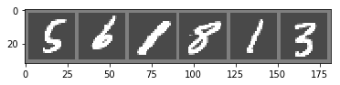

```python
def imshow(img):
    img = img / 2 + 0.5
    npimg = img.numpy()
    plt.imshow(np.transpose(npimg, (1, 2, 0)))

dataiter = iter(train_loader)
images, labels = dataiter.next()
images = images[:6]
labels = labels[:6]
imshow(torchvision.utils.make_grid(images))
print('labels: ' + ' '.join(str(labels[j].item()) for j in range(6)))
```

接下来我们就开始处理这些数据，我们的目标是训练一个深度神经网络，使得它可以自动分类 MNIST 中的手写数字 0～9．下面构造这个神经网络．它包括两个卷积层，一个 Dropout 层和两个全连接层，是一个典型的前馈网络．

```python
class Net(nn.Module):
    def __init__(self):
        super(Net, self).__init__()
        self.conv1 = nn.Conv2d(1, 10, kernel_size=5)
        self.conv2 = nn.Conv2d(10, 20, kernel_size=5)
        self.conv2_drop = nn.Dropout2d()
        self.fc1 = nn.Linear(320, 50)
        self.fc2 = nn.Linear(50, 10)

    def forward(self, x):
        x = f.relu(f.max_pool2d(self.conv1(x), 2))
        x = f.relu(f.max_pool2d(self.conv2_drop(self.conv2(x)), 2))
        x = x.view(-1, 320)
        x = f.relu(self.fc1(x))
        x = f.dropout(x, training=self.training)
        x = self.fc2(x)
        return f.log_softmax(x, dim=1)
```

而后我们定义训练、测试函数，以供之后的主程序在每个训练 epoch 中调用．注意在这里，我们每 5 个 batch 记录了一次 loss function 的值，以供之后可视化实用．

```python
def train(model, train_loader, optimizer, epoch, method):
    model.train()
    for batch_idx, (data, target) in enumerate(train_loader):
        optimizer.zero_grad()
        output = model(data)
        loss = f.nll_loss(output, target)
        loss.backward()
        optimizer.step()
        if batch_idx % 100 == 0:
            print('Train Epoch: {} [{}/{} ({:.0f}%)]\tLoss: {:.6f}'.format(
                epoch, batch_idx * len(data), len(train_loader.dataset),
                100. * batch_idx / len(train_loader), loss.item()))
        if batch_idx % 5 == 0:
            loss_data[method].append(loss.item())

def test(model, test_loader):
    model.eval()
    test_loss = 0
    correct = 0
    with torch.no_grad():
        for data, target in test_loader:
            output = model(data)
            test_loss += f.nll_loss(output, target, size_average=False).item() # sum up batch loss
            pred = output.max(1, keepdim=True)[1] # get the index of the max log-probability
            correct += pred.eq(target.view_as(pred)).sum().item()
    test_loss /= len(test_loader.dataset)
    print('\nTest set: Average loss: {:.4f}, Accuracy: {}/{} ({:.0f}%)\n'.format(
        test_loss, correct, len(test_loader.dataset),
        100. * correct / len(test_loader.dataset)))
```

```python
model = Net()
optimizer = optim.SGD(model.parameters(), lr=0.01, momentum=0.5)
for epoch in range(1, 3):  # 训练 2 个 epoch，并在测试集上进行测试
    train(model, train_loader, optimizer, epoch, 'sgd')
    test(model, test_loader)
```

```
Train Epoch: 1 [0/60000 (0%)]	Loss: 2.344421
Train Epoch: 1 [10000/60000 (17%)]	Loss: 2.040498
Train Epoch: 1 [20000/60000 (33%)]	Loss: 1.079268
Train Epoch: 1 [30000/60000 (50%)]	Loss: 0.939352
Train Epoch: 1 [40000/60000 (67%)]	Loss: 0.852773
Train Epoch: 1 [50000/60000 (83%)]	Loss: 0.641698

Test set: Average loss: 0.2806, Accuracy: 9282/10000 (93%)

Train Epoch: 2 [0/60000 (0%)]	Loss: 0.778714
Train Epoch: 2 [10000/60000 (17%)]	Loss: 0.613464
Train Epoch: 2 [20000/60000 (33%)]	Loss: 0.400296
Train Epoch: 2 [30000/60000 (50%)]	Loss: 0.352943
Train Epoch: 2 [40000/60000 (67%)]	Loss: 0.597212
Train Epoch: 2 [50000/60000 (83%)]	Loss: 0.385554

Test set: Average loss: 0.1698, Accuracy: 9512/10000 (95%)
```

之后使用 Adam 算法进行训练，选取学习率为 0.001．

```python
model = Net()
optimizer = optim.Adam(model.parameters(), lr=0.001)
for epoch in range(1, 3):
    train(model, train_loader, optimizer, epoch, 'adam')
    test(model, test_loader)
```

```
Train Epoch: 1 [0/60000 (0%)]	Loss: 2.334136
Train Epoch: 1 [10000/60000 (17%)]	Loss: 0.763064
Train Epoch: 1 [20000/60000 (33%)]	Loss: 0.564413
Train Epoch: 1 [30000/60000 (50%)]	Loss: 0.338037
Train Epoch: 1 [40000/60000 (67%)]	Loss: 0.325182
Train Epoch: 1 [50000/60000 (83%)]	Loss: 0.464362

Test set: Average loss: 0.1144, Accuracy: 9643/10000 (96%)

Train Epoch: 2 [0/60000 (0%)]	Loss: 0.389606
Train Epoch: 2 [10000/60000 (17%)]	Loss: 0.360544
Train Epoch: 2 [20000/60000 (33%)]	Loss: 0.388440
Train Epoch: 2 [30000/60000 (50%)]	Loss: 0.215659
Train Epoch: 2 [40000/60000 (67%)]	Loss: 0.131455
Train Epoch: 2 [50000/60000 (83%)]	Loss: 0.369611

Test set: Average loss: 0.0771, Accuracy: 9750/10000 (98%)
```

最后，我们使用 RMSProp 算法，选取学习率为 0.001．

```python
model = Net()
optimizer = optim.RMSprop(model.parameters(), lr=0.001)
for epoch in range(1, 3):
    train(model, train_loader, optimizer, epoch, 'rmsprop')
    test(model, test_loader)
```

```
Train Epoch: 1 [0/60000 (0%)]	Loss: 2.347979
Train Epoch: 1 [10000/60000 (17%)]	Loss: 0.711014
Train Epoch: 1 [20000/60000 (33%)]	Loss: 0.444715
Train Epoch: 1 [30000/60000 (50%)]	Loss: 0.339473
Train Epoch: 1 [40000/60000 (67%)]	Loss: 0.287785
Train Epoch: 1 [50000/60000 (83%)]	Loss: 0.406638

Test set: Average loss: 0.1008, Accuracy: 9703/10000 (97%)

Train Epoch: 2 [0/60000 (0%)]	Loss: 0.371953
Train Epoch: 2 [10000/60000 (17%)]	Loss: 0.423115
Train Epoch: 2 [20000/60000 (33%)]	Loss: 0.282886
Train Epoch: 2 [30000/60000 (50%)]	Loss: 0.168611
Train Epoch: 2 [40000/60000 (67%)]	Loss: 0.305751
Train Epoch: 2 [50000/60000 (83%)]	Loss: 0.323190

Test set: Average loss: 0.0658, Accuracy: 9790/10000 (98%)
```

现在我们得到了三种优化算法在训练过程中的 loss function 值数据．我们将这些数据绘出．

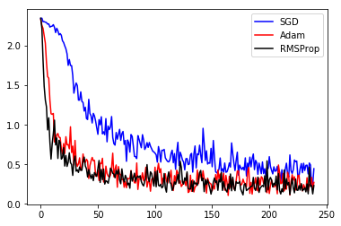

```python
%matplotlib inline
plt.plot(loss_data['sgd'], 'b-', loss_data['adam'], 'r-', loss_data['rmsprop'], 'k-')
plt.legend(['SGD', 'Adam', 'RMSProp'])
plt.show()
```

可以看到，使用自适应学习率算法 Adam 或 RMSProp 的优化速度明显比普通的 SGD 算法快，这体现了自适应学习率算法在训练深度神经网络中具有工程上的巨大优势．